# Исследование окупаемости рекламы развлекательного приложения Procrastinate Pro+

**Цель исследования -** изучить из каких стран приходят пользователи и какими устройствами они пользуются, определить сколько стоит привлечение пользователей из различных рекламных каналов, а также сколько денег приносит компании каждый клиент, проанализировать в каком случае расходы на привлечение клиента окупаются, установить какие факторы мешают привлечению клиентов.

**Задачи исследования -** ознакомится с представленными данными, выполнить предобработку, рассмотреть имеются ли пропуски, выявить наличие дубликатов, привести данные к нужным типам.

Провести исследовательский анализ данных, а именно: составить профили пользователей, выяснить на какую страну приходится больше всего платящих пользователей и какие устройства они предпочитают, установить из каких каналов пришло больше всего платящих пользователей.

Рассмотреть маркетинговые показатели, а именно рассчитать общую сумму расходов на маркетинг, посмотреть как траты распределены по рекламным источникам, визуализировать динамику изменения расходов по неделям и месяцам для каждого источника, вывести сколько в среднем стоило привлечение одного пользователя (CAC).

Завершающим этапом анализа будет оценка окупаемости рекламы. Узнаем окупается ли реклама, направленная на привлечение пользователей в целом, какие устройства, страны и рекламные каналы могут оказывать негативное влияние на окупаемость рекламы и чем могут быть вызваны проблемы окупаемости.

**Описание данных:**

Файл visits_info_short.csv хранит лог сервера с информацией о посещениях сайта, orders_info_short.csv — информацию о заказах, а costs_info_short.csv — информацию о расходах на рекламу.

*Структура visits_info_short:*

- User Id — уникальный идентификатор пользователя,
- Region — страна пользователя,
- Device — тип устройства пользователя,
- Channel — идентификатор источника перехода,
- Session Start — дата и время начала сессии,
- Session End — дата и время окончания сессии.

*Структура orders_info_short:*

- User Id — уникальный идентификатор пользователя,
- Event Dt — дата и время покупки,
- Revenue — сумма заказа.

*Структура costs_info_short:*

- dt — дата проведения рекламной кампании,
- Channel — идентификатор рекламного источника,
- costs — расходы на эту кампанию.

### Загрузите данные и подготовьте их к анализу

```python
import pandas as pd
from datetime import datetime, timedelta
from matplotlib import pyplot as plt
import seaborn as sns
import numpy as np
```

```python
visits
```

|  | User Id | Region | Device | Channel | Session Start | Session End |
| --- | --- | --- | --- | --- | --- | --- |
| 0 | 981449118918 | United States | iPhone | organic | 2019-05-01 02:36:01 | 2019-05-01 02:45:01 |
| 1 | 278965908054 | United States | iPhone | organic | 2019-05-01 04:46:31 | 2019-05-01 04:47:35 |
| 2 | 590706206550 | United States | Mac | organic | 2019-05-01 14:09:25 | 2019-05-01 15:32:08 |
| 3 | 326433527971 | United States | Android | TipTop | 2019-05-01 00:29:59 | 2019-05-01 00:54:25 |
| 4 | 349773784594 | United States | Mac | organic | 2019-05-01 03:33:35 | 2019-05-01 03:57:40 |
| ... | ... | ... | ... | ... | ... | ... |
| 309896 | 329994900775 | UK | PC | LeapBob | 2019-10-31 13:28:12 | 2019-10-31 14:39:29 |
| 309897 | 334903592310 | France | PC | lambdaMediaAds | 2019-10-31 22:14:52 | 2019-10-31 22:39:36 |
| 309898 | 540102010126 | Germany | PC | organic | 2019-10-31 01:40:48 | 2019-10-31 01:41:31 |
| 309899 | 308736936846 | Germany | Mac | organic | 2019-10-31 07:37:34 | 2019-10-31 07:37:55 |
| 309900 | 109329042535 | Germany | PC | lambdaMediaAds | 2019-10-31 14:17:43 | 2019-10-31 15:17:04 |

309901 rows × 6 columns

```python
orders
```

|  | User Id | Event Dt | Revenue |
| --- | --- | --- | --- |
| 0 | 188246423999 | 2019-05-01 23:09:52 | 4.99 |
| 1 | 174361394180 | 2019-05-01 12:24:04 | 4.99 |
| 2 | 529610067795 | 2019-05-01 11:34:04 | 4.99 |
| 3 | 319939546352 | 2019-05-01 15:34:40 | 4.99 |
| 4 | 366000285810 | 2019-05-01 13:59:51 | 4.99 |
| ... | ... | ... | ... |
| 40207 | 651604369137 | 2019-10-31 16:19:07 | 4.99 |
| 40208 | 275341387049 | 2019-10-31 01:17:17 | 4.99 |
| 40209 | 374656616484 | 2019-10-31 06:17:29 | 4.99 |
| 40210 | 168548862926 | 2019-10-31 22:46:19 | 4.99 |
| 40211 | 329994900775 | 2019-10-31 13:29:06 | 4.99 |

40212 rows × 3 columns

```python
costs
```

|  | dt | Channel | costs |
| --- | --- | --- | --- |
| 0 | 2019-05-01 | FaceBoom | 113.3 |
| 1 | 2019-05-02 | FaceBoom | 78.1 |
| 2 | 2019-05-03 | FaceBoom | 85.8 |
| 3 | 2019-05-04 | FaceBoom | 136.4 |
| 4 | 2019-05-05 | FaceBoom | 122.1 |
| ... | ... | ... | ... |
| 1795 | 2019-10-23 | lambdaMediaAds | 4.0 |
| 1796 | 2019-10-24 | lambdaMediaAds | 6.4 |
| 1797 | 2019-10-25 | lambdaMediaAds | 8.8 |
| 1798 | 2019-10-26 | lambdaMediaAds | 8.8 |
| 1799 | 2019-10-27 | lambdaMediaAds | 12.0 |

1800 rows × 3 columns

```python
visits.info()
```

```
<class 'pandas.core.frame.DataFrame'>
RangeIndex: 309901 entries, 0 to 309900
Data columns (total 6 columns):
 #   Column         Non-Null Count   Dtype
---  ------         --------------   -----
 0   User Id        309901 non-null  int64
 1   Region         309901 non-null  object
 2   Device         309901 non-null  object
 3   Channel        309901 non-null  object
 4   Session Start  309901 non-null  object
 5   Session End    309901 non-null  object
dtypes: int64(1), object(5)
memory usage: 14.2+ MB
```

```python
visits['Session Start'] = pd.to_datetime(visits['Session Start'], format="%Y-%m-%d %H:%M:%S")
visits['Session End'] = pd.to_datetime(visits['Session End'], format="%Y-%m-%d %H:%M:%S")
```

```python
visits.columns = visits.columns.str.lower()
visits.columns = visits.columns.str.replace(' ', '_')
```

```python
visits['session_start'] = pd.to_datetime(visits['session_start'])
visits['session_end'] = pd.to_datetime(visits['session_end'])
```

```python
visits['user_id'].value_counts()
```

```
33606575057     46
943775408561    36
901180916748    35
870784569391    34
764086596354    33
                ..
350468480225     1
748123264144     1
909267360937     1
816252757222     1
425788122907     1
Name: user_id, Length: 150008, dtype: int64
```

Уникальных пользователей 150008, есть пользователи совершающие повторные покупки.

```python
visits['region'].value_counts()
```

```
United States    207327
UK                36419
France            35396
Germany           30759
Name: region, dtype: int64
```

```python
visits['device'].value_counts()
```

```
iPhone     112603
Android     72590
PC          62686
Mac         62022
Name: device, dtype: int64
```

```python
visits['channel'].value_counts()
```

```
organic               107760
TipTop                 54794
FaceBoom               49022
WahooNetBanner         20465
LeapBob                17013
OppleCreativeMedia     16794
RocketSuperAds         12724
YRabbit                 9053
MediaTornado            8878
AdNonSense              6891
lambdaMediaAds          6507
Name: channel, dtype: int64
```

```python
visits['session_start'].value_counts()
```

```
2019-06-27 14:56:41    3
2019-10-10 22:50:07    3
2019-08-24 12:06:37    3
2019-10-22 17:17:39    3
2019-10-26 12:40:03    3
                      ..
2019-05-26 12:24:05    1
2019-08-28 17:43:34    1
2019-10-11 08:34:00    1
2019-05-13 07:58:36    1
2019-06-25 21:23:48    1
Name: session_start, Length: 306813, dtype: int64
```

```python
visits['session_end'].value_counts()
```

```
2019-08-04 10:32:15    3
2019-09-23 20:37:13    3
2019-08-03 06:31:26    3
2019-09-29 17:32:12    3
2019-09-26 08:30:19    3
                      ..
2019-10-27 23:08:22    1
2019-08-25 01:02:51    1
2019-06-17 02:33:04    1
2019-10-16 03:17:54    1
2019-05-08 23:10:58    1
Name: session_end, Length: 306793, dtype: int64
```

```python
visits.duplicated().sum()
#дубликаты не обнаружены
```

```
0
```

```python
orders.info()
```

```
<class 'pandas.core.frame.DataFrame'>
RangeIndex: 40212 entries, 0 to 40211
Data columns (total 3 columns):
 #   Column    Non-Null Count  Dtype
---  ------    --------------  -----
 0   User Id   40212 non-null  int64
 1   Event Dt  40212 non-null  object
 2   Revenue   40212 non-null  float64
dtypes: float64(1), int64(1), object(1)
memory usage: 942.6+ KB
```

```python
orders['Event Dt'] = pd.to_datetime(orders['Event Dt'], format = "%Y-%m-%d %H:%M:%S")
```

```python
orders.columns = orders.columns.str.lower()
orders.columns = orders.columns.str.replace(' ', '_')
```

```python
orders['event_dt'] = pd.to_datetime(orders['event_dt'])
```

```python
orders['user_id'].value_counts()
```

```
901180916748    22
883098437811    20
75337957494     19
512471511263    19
295795879965    19
                ..
237296010927     1
319939546352     1
742075710598     1
202972423389     1
775233404832     1
Name: user_id, Length: 8881, dtype: int64
```

```python
orders['event_dt'].value_counts()
```

```
2019-09-29 09:03:24    2
2019-10-25 16:24:24    2
2019-09-27 03:56:55    2
2019-08-12 22:50:49    2
2019-09-09 20:01:39    2
                      ..
2019-09-26 04:24:10    1
2019-10-26 06:25:45    1
2019-07-10 17:04:38    1
2019-08-06 08:55:42    1
2019-09-25 16:41:33    1
Name: event_dt, Length: 40163, dtype: int64
```

```python
orders['revenue'].value_counts()
```

```
4.99     38631
5.99       780
9.99       385
49.99      212
19.99      204
Name: revenue, dtype: int64
```

```python
orders.duplicated().sum()
#дубликаты не обнаружены
```

```
0
```

```python
costs.info()
```

```
<class 'pandas.core.frame.DataFrame'>
RangeIndex: 1800 entries, 0 to 1799
Data columns (total 3 columns):
 #   Column   Non-Null Count  Dtype
---  ------   --------------  -----
 0   dt       1800 non-null   object
 1   Channel  1800 non-null   object
 2   costs    1800 non-null   float64
dtypes: float64(1), object(2)
memory usage: 42.3+ KB
```

```python
costs['dt'] = pd.to_datetime(costs['dt'], format = "%Y-%m-%d")
```

```python
costs.columns = costs.columns.str.lower()
```

```python
costs['dt'] = pd.to_datetime(costs['dt']).dt.date
```

```python
costs['dt'].value_counts()
```

```
2019-09-13    10
2019-08-02    10
2019-10-04    10
2019-06-01    10
2019-08-01    10
              ..
2019-07-17    10
2019-07-26    10
2019-05-10    10
2019-06-30    10
2019-09-26    10
Name: dt, Length: 180, dtype: int64
```

```python
costs['channel'].value_counts()
```

```
WahooNetBanner        180
MediaTornado          180
OppleCreativeMedia    180
lambdaMediaAds        180
YRabbit               180
RocketSuperAds        180
TipTop                180
AdNonSense            180
LeapBob               180
FaceBoom              180
Name: channel, dtype: int64
```

```python
costs['costs'].value_counts()
```

```
6.40      26
3.36      21
9.60      20
16.80     19
4.32      17
          ..
217.80     1
186.20     1
176.70     1
273.00     1
55.00      1
Name: costs, Length: 608, dtype: int64
```

```python
costs.duplicated().sum()
#дубликаты не обнаружены
```

```
0
```

```python
visits.isna().sum() #посмотрим на количество пропусков
```

```
user_id          0
region           0
device           0
channel          0
session_start    0
session_end      0
dtype: int64
```

```python
orders.isna().sum() #посмотрим на количество пропусков
```

```
user_id     0
event_dt    0
revenue     0
dtype: int64
```

```python
costs.isna().sum() #посмотрим на количество пропусков
```

```
dt         0
channel    0
costs      0
dtype: int64
```

**Вывод:**

Выполнена предобработка данных, а именно: изменены типы данных у столбцов с датой и временем, все названия столбцов были приведены к нижнему регистру, дубликатов в строках ни в одной из трёх таблиц не найдено, пропуски в данных не обнаружены.

В таблице о заказах 40212 записей, 8881 пользователей оформивших заказы, а в таблице с затратами на маркетинг 1800 записей с 180 уникальными датами.

### Задайте функции для расчёта и анализа LTV, ROI, удержания и конверсии.

Разрешается использовать функции, с которыми вы познакомились в теоретических уроках.

Это функции для вычисления значений метрик:

- `get_profiles()` — для создания профилей пользователей,
- `get_retention()` — для подсчёта Retention Rate,
- `get_conversion()` — для подсчёта конверсии,
- `get_ltv()` — для подсчёта LTV.

А также функции для построения графиков:

- `filter_data()` — для сглаживания данных,
- `plot_retention()` — для построения графика Retention Rate,
- `plot_conversion()` — для построения графика конверсии,
- `plot_ltv_roi` — для визуализации LTV и ROI.

#### Функция для создания пользовательских профилей:

```python
def get_profiles(sessions, orders, events, ad_costs, event_names=[]):

    # находим параметры первых посещений
    profiles = (
        sessions.sort_values(by=['user_id', 'session_start'])
        .groupby('user_id')
        .agg(
            {
                'session_start': 'first',
                'channel': 'first',
                'device': 'first',
                'region': 'first',
            }
        )
        .rename(columns={'session_start': 'first_ts'})
        .reset_index()
    )

    # для когортного анализа определяем дату первого посещения
    # и первый день месяца, в который это посещение произошло
    profiles['dt'] = profiles['first_ts'].dt.date
    profiles['month'] = profiles['first_ts'].astype('datetime64[M]')

    # добавляем признак платящих пользователей
    profiles['payer'] = profiles['user_id'].isin(orders['user_id'].unique())

    # добавляем флаги для всех событий из event_names
    for event in event_names:
        if event in events['event_name'].unique():
            profiles[event] = profiles['user_id'].isin(
                events.query('event_name == @event')['user_id'].unique()
            )

    # считаем количество уникальных пользователей
    # с одинаковыми источником и датой привлечения
    new_users = (
        profiles.groupby(['dt', 'channel'])
        .agg({'user_id': 'nunique'})
        .rename(columns={'user_id': 'unique_users'})
        .reset_index()
    )

    # объединяем траты на рекламу и число привлечённых пользователей
    ad_costs = ad_costs.merge(new_users, on=['dt', 'channel'], how='left')

    # делим рекламные расходы на число привлечённых пользователей
    ad_costs['acquisition_cost'] = ad_costs['costs'] / ad_costs['unique_users']

    # добавляем стоимость привлечения в профили
    profiles = profiles.merge(
        ad_costs[['dt', 'channel', 'acquisition_cost']],
        on=['dt', 'channel'],
        how='left',
    )

    # стоимость привлечения органических пользователей равна нулю
    profiles['acquisition_cost'] = profiles['acquisition_cost'].fillna(0)

    return profiles
```

#### Функция для расчёта удержания:

```python
# функция для расчёта удержания

def get_retention(
    profiles,
    sessions,
    observation_date,
    horizon_days,
    dimensions=[],
    ignore_horizon=False,
):

    # добавляем столбец payer в передаваемый dimensions список
    dimensions = ['payer'] + dimensions

    # исключаем пользователей, не «доживших» до горизонта анализа
    last_suitable_acquisition_date = observation_date
    if not ignore_horizon:
        last_suitable_acquisition_date = observation_date - timedelta(
            days=horizon_days - 1
        )
    result_raw = profiles.query('dt <= @last_suitable_acquisition_date')

    # собираем «сырые» данные для расчёта удержания
    result_raw = result_raw.merge(
        sessions[['user_id', 'session_start']], on='user_id', how='left'
    )
    result_raw['lifetime'] = (
        result_raw['session_start'] - result_raw['first_ts']
    ).dt.days

    # функция для группировки таблицы по желаемым признакам
    def group_by_dimensions(df, dims, horizon_days):
        result = df.pivot_table(
            index=dims, columns='lifetime', values='user_id', aggfunc='nunique'
        )
        cohort_sizes = (
            df.groupby(dims)
            .agg({'user_id': 'nunique'})
            .rename(columns={'user_id': 'cohort_size'})
        )
        result = cohort_sizes.merge(result, on=dims, how='left').fillna(0)
        result = result.div(result['cohort_size'], axis=0)
        result = result[['cohort_size'] + list(range(horizon_days))]
        result['cohort_size'] = cohort_sizes
        return result

    # получаем таблицу удержания
    result_grouped = group_by_dimensions(result_raw, dimensions, horizon_days)

    # получаем таблицу динамики удержания
    result_in_time = group_by_dimensions(
        result_raw, dimensions + ['dt'], horizon_days
    )

    # возвращаем обе таблицы и сырые данные
    return result_raw, result_grouped, result_in_time
```

#### Функция для расчёта конверсии:

```python
def get_conversion(
    profiles,
    purchases,
    observation_date,
    horizon_days,
    dimensions=[],
    ignore_horizon=False,
):

    # исключаем пользователей, не «доживших» до горизонта анализа
    last_suitable_acquisition_date = observation_date
    if not ignore_horizon:
        last_suitable_acquisition_date = observation_date - timedelta(
            days=horizon_days - 1
        )
    result_raw = profiles.query('dt <= @last_suitable_acquisition_date')

    # определяем дату и время первой покупки для каждого пользователя
    first_purchases = (
        purchases.sort_values(by=['user_id', 'event_dt'])
        .groupby('user_id')
        .agg({'event_dt': 'first'})
        .reset_index()
    )

    # добавляем данные о покупках в профили
    result_raw = result_raw.merge(
        first_purchases[['user_id', 'event_dt']], on='user_id', how='left'
    )

    # рассчитываем лайфтайм для каждой покупки
    result_raw['lifetime'] = (
        result_raw['event_dt'] - result_raw['first_ts']
    ).dt.days

    # группируем по cohort, если в dimensions ничего нет
    if len(dimensions) == 0:
        result_raw['cohort'] = 'All users'
        dimensions = dimensions + ['cohort']

    # функция для группировки таблицы по желаемым признакам
    def group_by_dimensions(df, dims, horizon_days):
        result = df.pivot_table(
            index=dims, columns='lifetime', values='user_id', aggfunc='nunique'
        )
        result = result.fillna(0).cumsum(axis = 1)
        cohort_sizes = (
            df.groupby(dims)
            .agg({'user_id': 'nunique'})
            .rename(columns={'user_id': 'cohort_size'})
        )
        result = cohort_sizes.merge(result, on=dims, how='left').fillna(0)
        # делим каждую «ячейку» в строке на размер когорты
        # и получаем conversion rate
        result = result.div(result['cohort_size'], axis=0)
        result = result[['cohort_size'] + list(range(horizon_days))]
        result['cohort_size'] = cohort_sizes
        return result

    # получаем таблицу конверсии
    result_grouped = group_by_dimensions(result_raw, dimensions, horizon_days)

    # для таблицы динамики конверсии убираем 'cohort' из dimensions
    if 'cohort' in dimensions:
        dimensions = []

    # получаем таблицу динамики конверсии
    result_in_time = group_by_dimensions(
        result_raw, dimensions + ['dt'], horizon_days
    )

    # возвращаем обе таблицы и сырые данные
    return result_raw, result_grouped, result_in_time
```

#### Функция для расчёта LTV и ROI:

```python
def get_ltv(
    profiles,
    purchases,
    observation_date,
    horizon_days,
    dimensions=[],
    ignore_horizon=False,
):

    # исключаем пользователей, не «доживших» до горизонта анализа
    last_suitable_acquisition_date = observation_date
    if not ignore_horizon:
        last_suitable_acquisition_date = observation_date - timedelta(
            days=horizon_days - 1
        )
    result_raw = profiles.query('dt <= @last_suitable_acquisition_date')
    # добавляем данные о покупках в профили
    result_raw = result_raw.merge(
        purchases[['user_id', 'event_dt', 'revenue']], on='user_id', how='left'
    )
    # рассчитываем лайфтайм пользователя для каждой покупки
    result_raw['lifetime'] = (
        result_raw['event_dt'] - result_raw['first_ts']
    ).dt.days
    # группируем по cohort, если в dimensions ничего нет
    if len(dimensions) == 0:
        result_raw['cohort'] = 'All users'
        dimensions = dimensions + ['cohort']

    # функция группировки по желаемым признакам
    def group_by_dimensions(df, dims, horizon_days):
        # строим «треугольную» таблицу выручки
        result = df.pivot_table(
            index=dims, columns='lifetime', values='revenue', aggfunc='sum'
        )
        # находим сумму выручки с накоплением
        result = result.fillna(0).cumsum(axis=1)
        # вычисляем размеры когорт
        cohort_sizes = (
            df.groupby(dims)
            .agg({'user_id': 'nunique'})
            .rename(columns={'user_id': 'cohort_size'})
        )
        # объединяем размеры когорт и таблицу выручки
        result = cohort_sizes.merge(result, on=dims, how='left').fillna(0)
        # считаем LTV: делим каждую «ячейку» в строке на размер когорты
        result = result.div(result['cohort_size'], axis=0)
        # исключаем все лайфтаймы, превышающие горизонт анализа
        result = result[['cohort_size'] + list(range(horizon_days))]
        # восстанавливаем размеры когорт
        result['cohort_size'] = cohort_sizes

        # собираем датафрейм с данными пользователей и значениями CAC,
        # добавляя параметры из dimensions
        cac = df[['user_id', 'acquisition_cost'] + dims].drop_duplicates()

        # считаем средний CAC по параметрам из dimensions
        cac = (
            cac.groupby(dims)
            .agg({'acquisition_cost': 'mean'})
            .rename(columns={'acquisition_cost': 'cac'})
        )

        # считаем ROI: делим LTV на CAC
        roi = result.div(cac['cac'], axis=0)

        # удаляем строки с бесконечным ROI
        roi = roi[~roi['cohort_size'].isin([np.inf])]

        # восстанавливаем размеры когорт в таблице ROI
        roi['cohort_size'] = cohort_sizes

        # добавляем CAC в таблицу ROI
        roi['cac'] = cac['cac']

        # в финальной таблице оставляем размеры когорт, CAC
        # и ROI в лайфтаймы, не превышающие горизонт анализа
        roi = roi[['cohort_size', 'cac'] + list(range(horizon_days))]

        # возвращаем таблицы LTV и ROI
        return result, roi

    # получаем таблицы LTV и ROI
    result_grouped, roi_grouped = group_by_dimensions(
        result_raw, dimensions, horizon_days
    )

    # для таблиц динамики убираем 'cohort' из dimensions
    if 'cohort' in dimensions:
        dimensions = []

    # получаем таблицы динамики LTV и ROI
    result_in_time, roi_in_time = group_by_dimensions(
        result_raw, dimensions + ['dt'], horizon_days
    )

    return (
        result_raw,  # сырые данные
        result_grouped,  # таблица LTV
        result_in_time,  # таблица динамики LTV
        roi_grouped,  # таблица ROI
        roi_in_time,  # таблица динамики ROI
    )
```

#### Функция для сглаживания фрейма:

```python
def filter_data(df, window):
    # для каждого столбца применяем скользящее среднее
    for column in df.columns.values:
        df[column] = df[column].rolling(window).mean()
    return df
```

#### Функция для визуализации удержания:

```python
def plot_retention(retention, retention_history, horizon, window=7):

    # задаём размер сетки для графиков
    plt.figure(figsize=(15, 10))

    # исключаем размеры когорт и удержание первого дня
    retention = retention.drop(columns=['cohort_size', 0])
    # в таблице динамики оставляем только нужный лайфтайм
    retention_history = retention_history.drop(columns=['cohort_size'])[
        [horizon - 1]
    ]

    # если в индексах таблицы удержания только payer,
    # добавляем второй признак — cohort
    if retention.index.nlevels == 1:
        retention['cohort'] = 'All users'
        retention = retention.reset_index().set_index(['cohort', 'payer'])

    # в таблице графиков — два столбца и две строки, четыре ячейки
    # в первой строим кривые удержания платящих пользователей
    ax1 = plt.subplot(2, 2, 1)
    retention.query('payer == True').droplevel('payer').T.plot(
        grid=True, ax=ax1
    )
    plt.legend()
    plt.xlabel('Лайфтайм')
    plt.title('Удержание платящих пользователей')

    # во второй ячейке строим кривые удержания неплатящих
    # вертикальная ось — от графика из первой ячейки
    ax2 = plt.subplot(2, 2, 2, sharey=ax1)
    retention.query('payer == False').droplevel('payer').T.plot(
        grid=True, ax=ax2
    )
    plt.legend()
    plt.xlabel('Лайфтайм')
    plt.title('Удержание неплатящих пользователей')

    # в третьей ячейке — динамика удержания платящих
    ax3 = plt.subplot(2, 2, 3)
    # получаем названия столбцов для сводной таблицы
    columns = [
        name
        for name in retention_history.index.names
        if name not in ['dt', 'payer']
    ]
    # фильтруем данные и строим график
    filtered_data = retention_history.query('payer == True').pivot_table(
        index='dt', columns=columns, values=horizon - 1, aggfunc='mean'
    )
    filter_data(filtered_data, window).plot(grid=True, ax=ax3)
    plt.xlabel('Дата привлечения')
    plt.title(
        'Динамика удержания платящих пользователей на {}-й день'.format(
            horizon
        )
    )

    # в чётвертой ячейке — динамика удержания неплатящих
    ax4 = plt.subplot(2, 2, 4, sharey=ax3)
    # фильтруем данные и строим график
    filtered_data = retention_history.query('payer == False').pivot_table(
        index='dt', columns=columns, values=horizon - 1, aggfunc='mean'
    )
    filter_data(filtered_data, window).plot(grid=True, ax=ax4)
    plt.xlabel('Дата привлечения')
    plt.title(
        'Динамика удержания неплатящих пользователей на {}-й день'.format(
            horizon
        )
    )

    plt.tight_layout()
    plt.show()
```

#### Функция для визуализации конверсии:

```python
def plot_conversion(conversion, conversion_history, horizon, window=7):

    # задаём размер сетки для графиков
    plt.figure(figsize=(15, 5))

    # исключаем размеры когорт
    conversion = conversion.drop(columns=['cohort_size'])
    # в таблице динамики оставляем только нужный лайфтайм
    conversion_history = conversion_history.drop(columns=['cohort_size'])[
        [horizon - 1]
    ]

    # первый график — кривые конверсии
    ax1 = plt.subplot(1, 2, 1)
    conversion.T.plot(grid=True, ax=ax1)
    plt.legend()
    plt.xlabel('Лайфтайм')
    plt.title('Конверсия пользователей')

    # второй график — динамика конверсии
    ax2 = plt.subplot(1, 2, 2, sharey=ax1)
    columns = [
        # столбцами сводной таблицы станут все столбцы индекса, кроме даты
        name for name in conversion_history.index.names if name not in ['dt']
    ]
    filtered_data = conversion_history.pivot_table(
        index='dt', columns=columns, values=horizon - 1, aggfunc='mean'
    )
    filter_data(filtered_data, window).plot(grid=True, ax=ax2)
    plt.xlabel('Дата привлечения')
    plt.title('Динамика конверсии пользователей на {}-й день'.format(horizon))

    plt.tight_layout()
    plt.show()
```

#### Функция для визуализации LTV и ROI:

```python
def plot_ltv_roi(ltv, ltv_history, roi, roi_history, horizon, window=7):

    # задаём сетку отрисовки графиков
    plt.figure(figsize=(20, 10))

    # из таблицы ltv исключаем размеры когорт
    ltv = ltv.drop(columns=['cohort_size'])
    # в таблице динамики ltv оставляем только нужный лайфтайм
    ltv_history = ltv_history.drop(columns=['cohort_size'])[[horizon - 1]]

    # стоимость привлечения запишем в отдельный фрейм
    cac_history = roi_history[['cac']]

    # из таблицы roi исключаем размеры когорт и cac
    roi = roi.drop(columns=['cohort_size', 'cac'])
    # в таблице динамики roi оставляем только нужный лайфтайм
    roi_history = roi_history.drop(columns=['cohort_size', 'cac'])[
        [horizon - 1]
    ]

    # первый график — кривые ltv
    ax1 = plt.subplot(2, 3, 1)
    ltv.T.plot(grid=True, ax=ax1)
    plt.legend()
    plt.xlabel('Лайфтайм')
    plt.title('LTV')

    # второй график — динамика ltv
    ax2 = plt.subplot(2, 3, 2, sharey=ax1)
    # столбцами сводной таблицы станут все столбцы индекса, кроме даты
    columns = [name for name in ltv_history.index.names if name not in ['dt']]
    filtered_data = ltv_history.pivot_table(
        index='dt', columns=columns, values=horizon - 1, aggfunc='mean'
    )
    filter_data(filtered_data, window).plot(grid=True, ax=ax2)
    plt.xlabel('Дата привлечения')
    plt.title('Динамика LTV пользователей на {}-й день'.format(horizon))

    # третий график — динамика cac
    ax3 = plt.subplot(2, 3, 3, sharey=ax1)
    # столбцами сводной таблицы станут все столбцы индекса, кроме даты
    columns = [name for name in cac_history.index.names if name not in ['dt']]
    filtered_data = cac_history.pivot_table(
        index='dt', columns=columns, values='cac', aggfunc='mean'
    )
    filter_data(filtered_data, window).plot(grid=True, ax=ax3)
    plt.xlabel('Дата привлечения')
    plt.title('Динамика стоимости привлечения пользователей')

    # четвёртый график — кривые roi
    ax4 = plt.subplot(2, 3, 4)
    roi.T.plot(grid=True, ax=ax4)
    plt.axhline(y=1, color='red', linestyle='--', label='Уровень окупаемости')
    plt.legend()
    plt.xlabel('Лайфтайм')
    plt.title('ROI')

    # пятый график — динамика roi
    ax5 = plt.subplot(2, 3, 5, sharey=ax4)
    # столбцами сводной таблицы станут все столбцы индекса, кроме даты
    columns = [name for name in roi_history.index.names if name not in ['dt']]
    filtered_data = roi_history.pivot_table(
        index='dt', columns=columns, values=horizon - 1, aggfunc='mean'
    )
    filter_data(filtered_data, window).plot(grid=True, ax=ax5)
    plt.axhline(y=1, color='red', linestyle='--', label='Уровень окупаемости')
    plt.xlabel('Дата привлечения')
    plt.title('Динамика ROI пользователей на {}-й день'.format(horizon))

    plt.tight_layout()
    plt.show()
```

#### Момент и горизонт анализа:

```python
observation_date = datetime(2019, 11, 1).date()  # момент анализа
horizon_days = 14 # горизонт анализа
```

Установим момент анализа 1 ноября 2019 года, а горизонт анализа 14 дней, были заданы функции для расчёта и анализа LTV, ROI, удержания и конверсии.

### Исследовательский анализ данных

- Составьте профили пользователей. Определите минимальную и максимальную даты привлечения пользователей.
- Выясните, из каких стран пользователи приходят в приложение и на какую страну приходится больше всего платящих пользователей. Постройте таблицу, отражающую количество пользователей и долю платящих из каждой страны.
- Узнайте, какими устройствами пользуются клиенты и какие устройства предпочитают платящие пользователи. Постройте таблицу, отражающую количество пользователей и долю платящих для каждого устройства.
- Изучите рекламные источники привлечения и определите каналы, из которых пришло больше всего платящих пользователей. Постройте таблицу, отражающую количество пользователей и долю платящих для каждого канала привлечения.

После каждого пункта сформулируйте выводы.

#### **Составим профили пользователей и определим минимальную и максимальную дату привлечения пользователей.**

**Профили пользователей:**

```python
profiles = get_profiles(visits, orders, None, costs)
profiles.head()
```

|  | user_id | first_ts | channel | device | region | dt | month | payer | acquisition_cost |
| --- | --- | --- | --- | --- | --- | --- | --- | --- | --- |
| 0 | 599326 | 2019-05-07 20:58:57 | FaceBoom | Mac | United States | 2019-05-07 | 2019-05-01 | True | 1.088172 |
| 1 | 4919697 | 2019-07-09 12:46:07 | FaceBoom | iPhone | United States | 2019-07-09 | 2019-07-01 | False | 1.107237 |
| 2 | 6085896 | 2019-10-01 09:58:33 | organic | iPhone | France | 2019-10-01 | 2019-10-01 | False | 0.000000 |
| 3 | 22593348 | 2019-08-22 21:35:48 | AdNonSense | PC | Germany | 2019-08-22 | 2019-08-01 | False | 0.988235 |
| 4 | 31989216 | 2019-10-02 00:07:44 | YRabbit | iPhone | United States | 2019-10-02 | 2019-10-01 | False | 0.230769 |

**Минимальная и максимальная дата привлечения пользователей:**

```python
min_date = profiles['dt'].min()
max_date = profiles['dt'].max()
print(min_date, max_date)
```

```
2019-05-01 2019-10-27
```

Получили профили пользователей. Даты соотносятся с указанными в задании (с 1 мая по 27 октября 2019 года).

#### **Выясним из каких стран пользователи приходят в приложение и на какую страну приходится больше всего платящих пользователей. Построим таблицу, отражающую количество пользователей и долю платящих из каждой страны.**

```python
user_region = pd.DataFrame()
user_region['user'] = profiles.groupby('region')['user_id'].count()
user_region['user_share'] = ((user_region['user'] / profiles['region'].count()) * 100)
user_region.sort_values(by='user', ascending=False)
```

| region | user | user_share |
| --- | --- | --- |
| United States | 100002 | 66.664445 |
| UK | 17575 | 11.716042 |
| France | 17450 | 11.632713 |
| Germany | 14981 | 9.986801 |

Больше всего пользователей приходит из США (100002 пользователей или 66,7%), следом идут пользователи из Великобритании и Франции (по 11%), и меньше всего пользователей из Германии(10%).

```python
def get_profiles(visits, orders):

    profiles = (
        visits.sort_values(by=['user_id', 'session_start'])
        .groupby('user_id')
        .agg(
            {
                'session_start': 'first',
                'channel': 'first',
                'device': 'first',
                'region': 'first',
            }
        )
        .rename(columns={'session_start': 'first_ts'})
        .reset_index()
    )

    profiles['dt'] = profiles['first_ts'].dt.date
    profiles['month'] = profiles['first_ts'].astype('datetime64[M]')

    # проверьте, есть ли ID пользователей из profiles в orders
    profiles['payer'] =  profiles['user_id'].isin(orders['user_id'].unique()) # ваш код здесь

    return profiles

# строим профили по двум наборам данных
profiles = get_profiles(visits, orders)

payer_region = profiles.groupby('region').agg({'payer':'mean'}).sort_values(by='payer', ascending = False)
print(payer_region*100)
```

```
                  payer
region
United States  6.901862
Germany        4.111875
UK             3.982930
France         3.799427
```

Разбивка по платящим клиентам немного отличается, лидером опять является США с показателем 6902 пользователя или 6,9% от числа всех пользователей из США, следом идет Германия с показателем 4,1%, у Великабритании 4%, а у Франции 3,8%

**Узнаем какими устройствами пользуются клиенты и какие устройства предпочитают платящие пользователи. Построим таблицу, отражающую количество пользователей и долю платящих для каждого устройства.**

```python
user_device = pd.DataFrame()
user_device['user'] = profiles.groupby('device')['user_id'].count()
user_device['user_share'] = ((user_device['user'] / profiles['device'].count()) * 100)
user_device.sort_values(by='user', ascending=False)
```

| device | user | user_share |
| --- | --- | --- |
| iPhone | 54479 | 36.317396 |
| Android | 35032 | 23.353421 |
| PC | 30455 | 20.302251 |
| Mac | 30042 | 20.026932 |

Больше всего пользователей используют iPhone (36,3%), далее Android (23,4%), и по 20% у PC и Mac.

```python
def get_profiles(visits, orders):

    profiles = (
        visits.sort_values(by=['user_id', 'session_start'])
        .groupby('user_id')
        .agg(
            {
                'session_start': 'first',
                'channel': 'first',
                'device': 'first',
                'region': 'first',
            }
        )
        .rename(columns={'session_start': 'first_ts'})
        .reset_index()
    )

    profiles['dt'] = profiles['first_ts'].dt.date
    profiles['month'] = profiles['first_ts'].astype('datetime64[M]')

    # проверьте, есть ли ID пользователей из profiles в orders
    profiles['payer'] =  profiles['user_id'].isin(orders['user_id'].unique()) # ваш код здесь

    return profiles

# строим профили по двум наборам данных
profiles = get_profiles(visits, orders)

payer_device = profiles.groupby('device').agg({'payer':'mean'}).sort_values(by='payer', ascending = False)
print(payer_device*100)
```

```
            payer
device
Mac      6.364423
iPhone   6.207897
Android  5.851793
PC       5.046790
```

Доля платящих примерно равная на устройствах, но больше у Mac(6,4%) и iPhone (6,2%), у Android 5,9%, PC 5%.

**Изучим рекламные источники привлечения и определим каналы, из которых пришло больше всего платящих пользователей. Построим таблицу, отражающую количество пользователей и долю платящих для каждого канала привлечения**

```python
user_channel = pd.DataFrame()
user_channel['user'] = profiles.groupby('channel')['user_id'].count()
user_channel['user_share'] = ((user_channel['user'] / profiles['channel'].count()) * 100)
user_channel.sort_values(by='user', ascending=False)
```

| channel | user | user_share |
| --- | --- | --- |
| organic | 56439 | 37.623993 |
| FaceBoom | 29144 | 19.428297 |
| TipTop | 19561 | 13.039971 |
| OppleCreativeMedia | 8605 | 5.736361 |
| LeapBob | 8553 | 5.701696 |
| WahooNetBanner | 8553 | 5.701696 |
| RocketSuperAds | 4448 | 2.965175 |
| MediaTornado | 4364 | 2.909178 |
| YRabbit | 4312 | 2.874513 |
| AdNonSense | 3880 | 2.586529 |
| lambdaMediaAds | 2149 | 1.432590 |

Среди лидеров по каналу привлечения идут каналы: organic - 37,6% FaceBoom - 19,4% TipTop - 13,0%

```python
def get_profiles(visits, orders):

    profiles = (
        visits.sort_values(by=['user_id', 'session_start'])
        .groupby('user_id')
        .agg(
            {
                'session_start': 'first',
                'channel': 'first',
                'device': 'first',
                'region': 'first',
            }
        )
        .rename(columns={'session_start': 'first_ts'})
        .reset_index()
    )

    profiles['dt'] = profiles['first_ts'].dt.date
    profiles['month'] = profiles['first_ts'].astype('datetime64[M]')

    # проверьте, есть ли ID пользователей из profiles в orders
    profiles['payer'] =  profiles['user_id'].isin(orders['user_id'].unique()) # ваш код здесь

    return profiles

# строим профили по двум наборам данных
profiles = get_profiles(visits, orders)

payer_channel = profiles.groupby('channel').agg({'payer':'mean'}).sort_values(by='payer', ascending = False)
print(payer_channel*100)
```

```
                        payer
channel
FaceBoom            12.204914
AdNonSense          11.340206
lambdaMediaAds      10.469986
TipTop               9.600736
RocketSuperAds       7.913669
WahooNetBanner       5.296387
YRabbit              3.826531
MediaTornado         3.574702
LeapBob              3.063253
OppleCreativeMedia   2.707728
organic              2.055316
```

По параметру платящих клиентов лидируют каналы: FaceBoom - 12,2 AdNonSense - 11,3% lambdaMediaAds - 10,5%

Таким образом, на данном этапе были определены лидеры стран по количеству пользователей - больше всего пользователей приходит из США (100002 пользователей или 66,7%), следом идут пользователи из Великобритании и Франции (по 11%), и меньше всего пользователей из Германии(10%).

Разбивка по платящим клиентам немного отличается, лидером опять является СЩА с показателем 6902 пользователя или 6,9% от числа всех пользователей из США, следом идет Германия с показателем 4,1%, у Великабритании 4%, а у Франции 3,8%.

Разбивка по устройствам выглдит следующим образом, iPhone (36,3%), следом Android (23,4%), и по 20% у PC и Mac.

Доля платящих примерно равная на устройствах, но больше у Mac(6,4%) и iPhone (6,2%), у Android 5,9%, PC 5%.

Лидеры каналов привлечения идут каналы: organic - 37,6% FaceBoom - 19,4% TipTop - 13,0% По параметру платящих клиентов лидируют каналы: FaceBoom - 12,2 AdNonSense - 11,3% lambdaMediaAds - 10,5%.

### Маркетинг

- Посчитайте общую сумму расходов на маркетинг.
- Выясните, как траты распределены по рекламным источникам, то есть сколько денег потратили на каждый источник.
- Постройте визуализацию динамики изменения расходов во времени (по неделям и месяцам) по каждому источнику. Постарайтесь отразить это на одном графике.
- Узнайте, сколько в среднем стоило привлечение одного пользователя (CAC) из каждого источника. Используйте профили пользователей.

Напишите промежуточные выводы.

**Посчитаем общую сумму расходов на маркетинг.**

```python
cos = costs['costs'].sum()
round(cos, 2)
```

```
105497.3
```

Всего было потрачено на маркетинг 105497.3

**Выясним, как траты распределены по рекламным источникам, то есть сколько денег потратили на каждый источник.**

```python
expense = pd.DataFrame()
expense['expense'] = costs.groupby('channel')['costs'].sum()
expense['expense_share'] = expense['expense'] / cos * 100
expense.sort_values(by='expense', ascending=False)
```

| channel | expense | expense_share |
| --- | --- | --- |
| TipTop | 54751.30 | 51.898295 |
| FaceBoom | 32445.60 | 30.754910 |
| WahooNetBanner | 5151.00 | 4.882589 |
| AdNonSense | 3911.25 | 3.707441 |
| OppleCreativeMedia | 2151.25 | 2.039152 |
| RocketSuperAds | 1833.00 | 1.737485 |
| LeapBob | 1797.60 | 1.703930 |
| lambdaMediaAds | 1557.60 | 1.476436 |
| MediaTornado | 954.48 | 0.904744 |
| YRabbit | 944.22 | 0.895018 |

Половина всех трат приходится на TipTop (51,9%), далее идет FaceBoom с показателем 30,8%, по другим каналам сумма не превышала 5%.

**Построим визуализацию динамики изменения расходов во времени (по неделям и месяцам) по каждому источнику.**

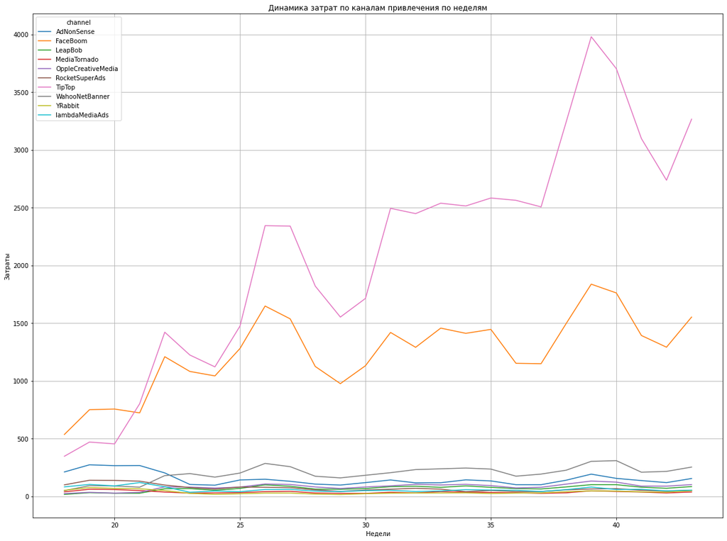

```python
costs.pivot_table(index=pd.to_datetime(costs['dt']).dt.isocalendar().week, columns='channel', values='costs', aggfunc='sum').plot(figsize=(20, 15),grid=True)
plt.xlabel('Недели')
plt.ylabel('Затраты')
plt.title('Динамика затрат по каналам привлечения по неделям')
plt.show()
```

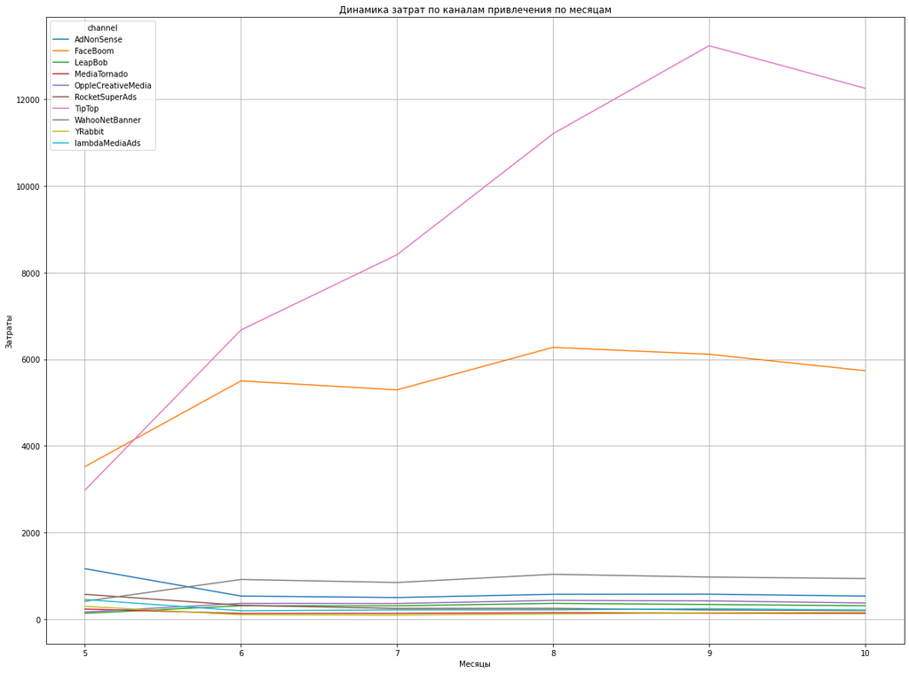

```python
costs.pivot_table(index=pd.to_datetime(costs['dt']).dt.month, columns='channel', values='costs', aggfunc='sum').plot(figsize=(20, 15),grid=True)
plt.xlabel('Месяцы')
plt.ylabel('Затраты')
plt.title('Динамика затрат по каналам привлечения по месяцам')
plt.show()
```

На графике прослеживается рост затрат у TipTop и FaceBoom, при относительной стабильности остальных каналов.

**Узнаем сколько в среднем стоило привлечение одного пользователя (CAC) из каждого источника. Используем профили пользователей**

```python
def get_profiles(sessions, orders, events, ad_costs, event_names=[]):

    # находим параметры первых посещений
    profiles = (
        sessions.sort_values(by=['user_id', 'session_start'])
        .groupby('user_id')
        .agg(
            {
                'session_start': 'first',
                'channel': 'first',
                'device': 'first',
                'region': 'first',
            }
        )
        .rename(columns={'session_start': 'first_ts'})
        .reset_index()
    )

    # для когортного анализа определяем дату первого посещения
    # и первый день месяца, в который это посещение произошло
    profiles['dt'] = profiles['first_ts'].dt.date
    profiles['month'] = profiles['first_ts'].astype('datetime64[M]')

    # добавляем признак платящих пользователей
    profiles['payer'] = profiles['user_id'].isin(orders['user_id'].unique())

    # добавляем флаги для всех событий из event_names
    for event in event_names:
        if event in events['event_name'].unique():
            profiles[event] = profiles['user_id'].isin(
                events.query('event_name == @event')['user_id'].unique()
            )

    # считаем количество уникальных пользователей
    # с одинаковыми источником и датой привлечения
    new_users = (
        profiles.groupby(['dt', 'channel'])
        .agg({'user_id': 'nunique'})
        .rename(columns={'user_id': 'unique_users'})
        .reset_index()
    )

    # объединяем траты на рекламу и число привлечённых пользователей
    ad_costs = ad_costs.merge(new_users, on=['dt', 'channel'], how='left')

    # делим рекламные расходы на число привлечённых пользователей
    ad_costs['acquisition_cost'] = ad_costs['costs'] / ad_costs['unique_users']

    # добавляем стоимость привлечения в профили
    profiles = profiles.merge(
        ad_costs[['dt', 'channel', 'acquisition_cost']],
        on=['dt', 'channel'],
        how='left',
    )

    # стоимость привлечения органических пользователей равна нулю
    profiles['acquisition_cost'] = profiles['acquisition_cost'].fillna(0)

    return profiles
```

```python
profiles = get_profiles(visits, orders, None, costs)
profiles.head()
```

|  | user_id | first_ts | channel | device | region | dt | month | payer | acquisition_cost |
| --- | --- | --- | --- | --- | --- | --- | --- | --- | --- |
| 0 | 599326 | 2019-05-07 20:58:57 | FaceBoom | Mac | United States | 2019-05-07 | 2019-05-01 | True | 1.088172 |
| 1 | 4919697 | 2019-07-09 12:46:07 | FaceBoom | iPhone | United States | 2019-07-09 | 2019-07-01 | False | 1.107237 |
| 2 | 6085896 | 2019-10-01 09:58:33 | organic | iPhone | France | 2019-10-01 | 2019-10-01 | False | 0.000000 |
| 3 | 22593348 | 2019-08-22 21:35:48 | AdNonSense | PC | Germany | 2019-08-22 | 2019-08-01 | False | 0.988235 |
| 4 | 31989216 | 2019-10-02 00:07:44 | YRabbit | iPhone | United States | 2019-10-02 | 2019-10-01 | False | 0.230769 |

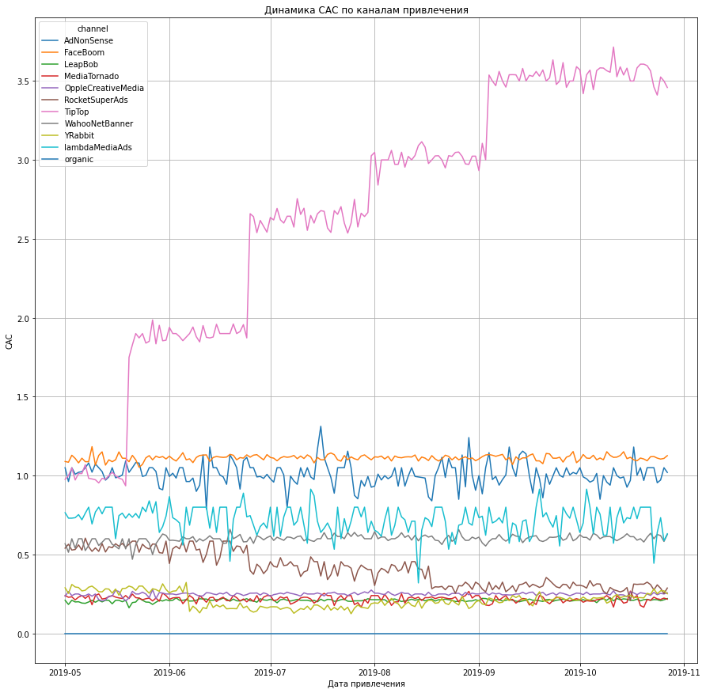

```python
profiles.pivot_table(
    index='dt', columns='channel', values='acquisition_cost', aggfunc='mean'
).plot(grid=True, figsize=(15, 15))
plt.ylabel('CAC')
plt.xlabel('Дата привлечения')
plt.title('Динамика САС по каналам привлечения')
plt.show()
```

```python
cac = pd.DataFrame()
cac['mean'] = profiles.groupby('channel')['acquisition_cost'].mean()
cac.sort_values(by='mean', ascending=False)
```

| channel | mean |
| --- | --- |
| TipTop | 2.799003 |
| FaceBoom | 1.113286 |
| AdNonSense | 1.008054 |
| lambdaMediaAds | 0.724802 |
| WahooNetBanner | 0.602245 |
| RocketSuperAds | 0.412095 |
| OppleCreativeMedia | 0.250000 |
| YRabbit | 0.218975 |
| MediaTornado | 0.218717 |
| LeapBob | 0.210172 |
| organic | 0.000000 |

По графику прослеживается увелечение средней стоимости привлечения одного клиента у TipTop с 1 до 3,5, при относительной стабильности других каналов (не более 1,5).

При общей сумме затрат на маркетинг 105497.3, Половина всех трат приходится на TipTop (51,9%), далее идет на FaceBoom с показателем 30,8%, по другим каналам сумма не превышала 5%.

Заметен рост затрат на протяжении всего периода у TipTop и FaceBoom, но следует заметить, что прослеживается увелечение средней стоимости привлечения одного клиента у TipTop с 1 до 3,5, при относительной стабильности других каналов (не более 1,5), что может быть сигналом для пересмотра рекламного бюджета на данный канал.

### Оцените окупаемость рекламы

Используя графики LTV, ROI и CAC, проанализируйте окупаемость рекламы. Считайте, что на календаре 1 ноября 2019 года, а в бизнес-плане заложено, что пользователи должны окупаться не позднее чем через две недели после привлечения. Необходимость включения в анализ органических пользователей определите самостоятельно.

- Проанализируйте окупаемость рекламы c помощью графиков LTV и ROI, а также графики динамики LTV, CAC и ROI.
- Проверьте конверсию пользователей и динамику её изменения. То же самое сделайте с удержанием пользователей. Постройте и изучите графики конверсии и удержания.
- Проанализируйте окупаемость рекламы с разбивкой по устройствам. Постройте графики LTV и ROI, а также графики динамики LTV, CAC и ROI.
- Проанализируйте окупаемость рекламы с разбивкой по странам. Постройте графики LTV и ROI, а также графики динамики LTV, CAC и ROI.
- Проанализируйте окупаемость рекламы с разбивкой по рекламным каналам. Постройте графики LTV и ROI, а также графики динамики LTV, CAC и ROI.
- Ответьте на такие вопросы:
  - Окупается ли реклама, направленная на привлечение пользователей в целом?
  - Какие устройства, страны и рекламные каналы могут оказывать негативное влияние на окупаемость рекламы?
  - Чем могут быть вызваны проблемы окупаемости?

Напишите вывод, опишите возможные причины обнаруженных проблем и промежуточные рекомендации для рекламного отдела.

**Проанализируем окупаемость рекламы c помощью графиков LTV и ROI, а также графиков динамики LTV, CAC и ROI**

```python
# исключим органический трафик
profiles = profiles.query('channel !="organic"')
```

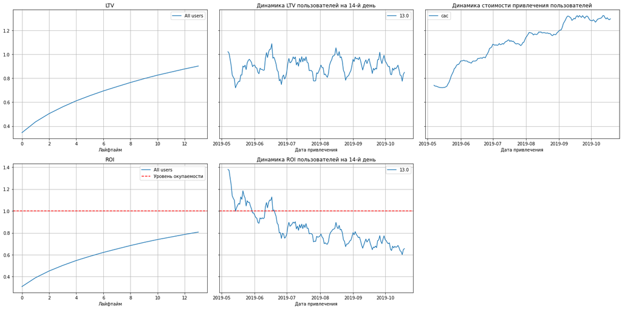

```python
# посчитаем LTV и ROI
ltv_raw, ltv_grouped, ltv_history, roi_grouped, roi_history = get_ltv(
    profiles, orders, observation_date, horizon_days
)
# строим графики
plot_ltv_roi(ltv_grouped, ltv_history, roi_grouped, roi_history, horizon_days)
```

Реклама не окупается, проблема в том, что к концу второй недели ROI на уровне 80%.

CAC увеличивается на протяжении всей компании, что является плохим сигналом.

На LTV влияет сезонный фактор, но и этот показатель достаточно стабилен. Значит, дело не в ухудшении качества пользователей.

**Проверим конверсию с удержанием пользователей и динамику их изменений.**

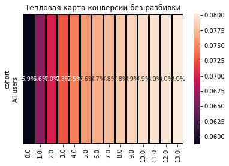

```python
# считаем конверсию без параметра dimensions
conversion_raw, conversion, conversion_history = get_conversion(
    profiles, orders, datetime(2019, 11, 1).date(), 14
)

# строим хитмэп по таблице конверсии
sns.heatmap(conversion.drop(columns=['cohort_size']), annot=True, fmt='.1%', linewidths=2, linecolor='black')
plt.title('Тепловая карта конверсии без разбивки')
sns.set(rc = {'figure.figsize':(10,5)})
plt.show()
```

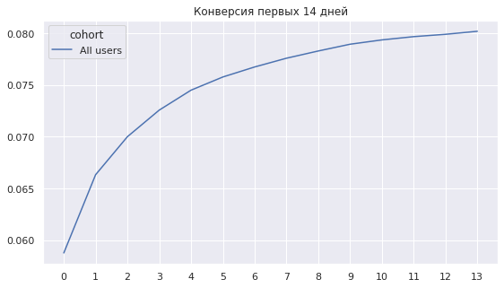

```python
conversion_raw, conversion, conversion_history = get_conversion(
    profiles, orders, datetime(2019, 11, 1).date(), 14
)

plt.figure(figsize=(20, 5)) # размер сетки для графиков

# для кривых конверсии исключаем размеры когорт
report = conversion.drop(columns=['cohort_size'])
report.T.plot(
    # строим кривые конверсии в первой ячейке таблицы графиков
    grid=True, xticks=list(report.columns.values), ax=plt.subplot(1, 2, 1)
)
plt.title('Конверсия первых 14 дней')


plt.show()
```

Общая конверсия растёт от 5,9% в первый день «жизни» пользователей до 8 % на четырнадцатый день, причем во вторую неделю рост практически отсутствует.

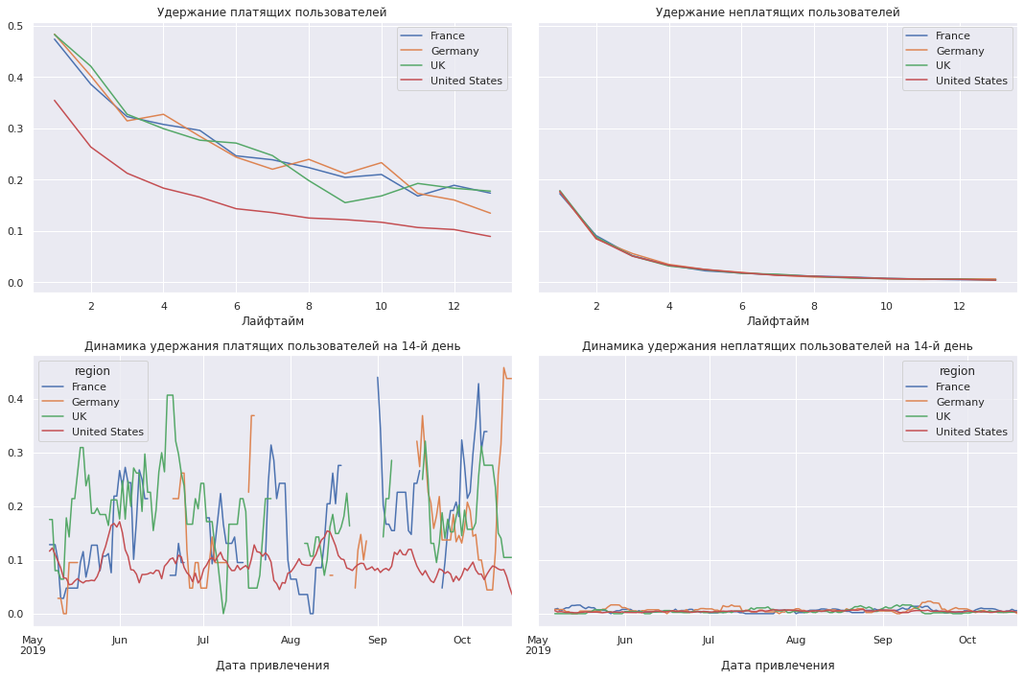

```python
# смотрим удержание с разбивкой по странам
dimensions = ['region']

retention_raw, retention_grouped, retention_history = get_retention(
    profiles, visits, observation_date, horizon_days, dimensions=dimensions
)

plot_retention(retention_grouped, retention_history, horizon_days)
```

Заметно, что при самой высокой конверсии, удержиние платящих пользователей из США самое низкое.

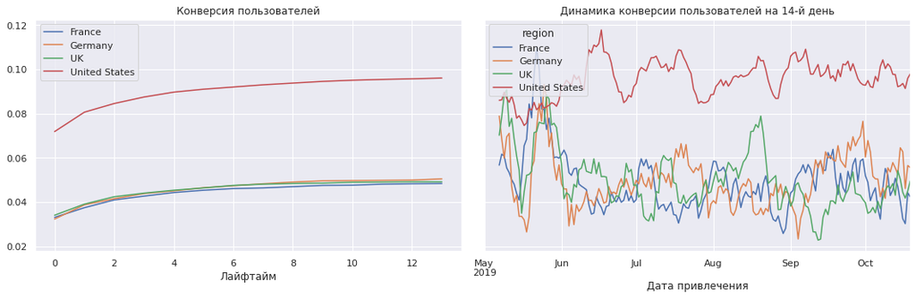

```python
# смотрим конверсию с разбивкой по странам

conversion_raw, conversion_grouped, conversion_history = get_conversion(
    profiles, orders, observation_date, horizon_days, dimensions=dimensions
)

plot_conversion(conversion_grouped, conversion_history, horizon_days)
```

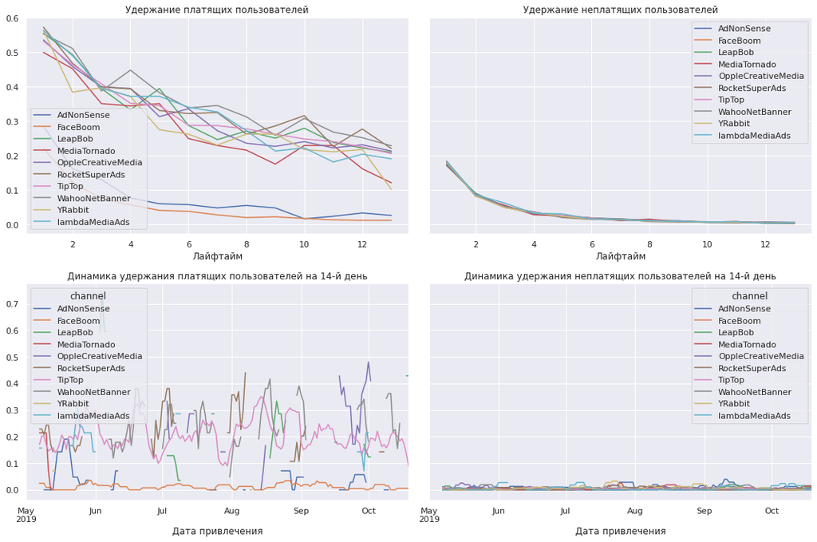

```python
# смотрим удержание с разбивкой по каналам
dimensions = ['channel']

retention_raw, retention_grouped, retention_history = get_retention(
    profiles, visits, observation_date, horizon_days, dimensions=dimensions
)

plot_retention(retention_grouped, retention_history, horizon_days)
```

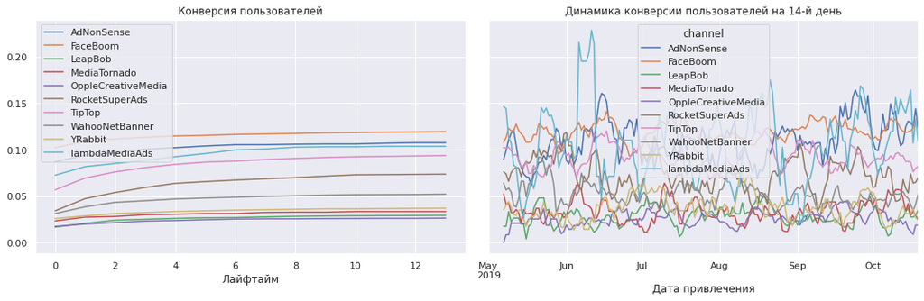

```python
# смотрим конверсию с разбивкой по каналам
dimensions = ['channel']

conversion_raw, conversion_grouped, conversion_history = get_conversion(
    profiles, orders, observation_date, horizon_days, dimensions=dimensions
)

plot_conversion(conversion_grouped, conversion_history, horizon_days)
```

Лидеры по конверсии AdNonSense и FaceBoom имеют самые худшие показатели по удержанию, что давольно странно, так как графики сопостовимы с удержанием неплатящих клиентов, а вот 3 по конверсии канал lambdaMediaAds имеет довольно неплохое удержание.

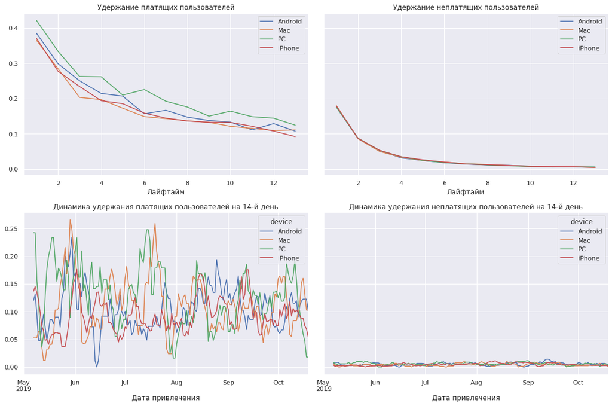

```python
# смотрим удержание с разбивкой по устройствам
dimensions = ['device']

retention_raw, retention_grouped, retention_history = get_retention(
    profiles, visits, observation_date, horizon_days, dimensions=dimensions
)

plot_retention(retention_grouped, retention_history, horizon_days)
```

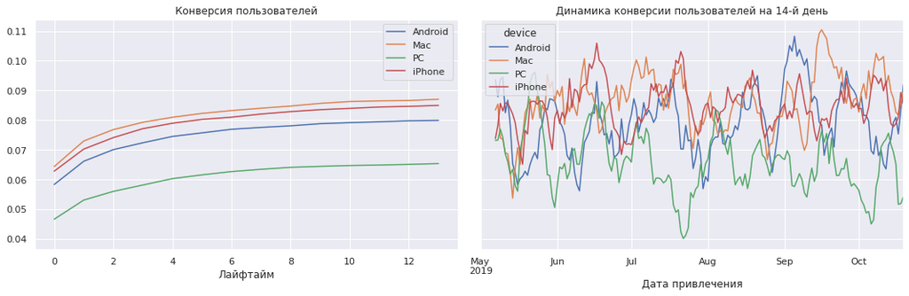

```python
# смотрим конверсию с разбивкой по устройствам

conversion_raw, conversion_grouped, conversion_history = get_conversion(
    profiles, orders, observation_date, horizon_days, dimensions=dimensions
)

plot_conversion(conversion_grouped, conversion_history, horizon_days)
```

**Проанализирим окупаемость рекламы с разбивкой по устройствам. Построим графики LTV и ROI, а также графики динамики LTV, CAC и ROI**

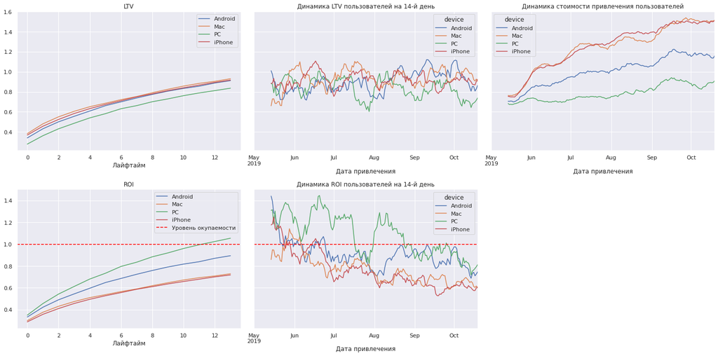

```python
# смотрим окупаемость с разбивкой по устройствам
dimensions = ['device']

ltv_raw, ltv_grouped, ltv_history, roi_grouped, roi_history = get_ltv(
    profiles, orders, observation_date, horizon_days, dimensions=dimensions
)

plot_ltv_roi(
    ltv_grouped, ltv_history, roi_grouped, roi_history, horizon_days, window=14
)
```

Окупаются только пользователи РС (на 11 день) при самой низкой стоимости привлечения, однако по всем показателям прослеживается рост. На LTV влияет сезонный фактор, но и этот показатель достаточно стабилен по всем устройствам.

**Проанализируем окупаемость рекламы с разбивкой по странам. Построим графики LTV и ROI, а также графики динамики LTV, CAC и ROI**

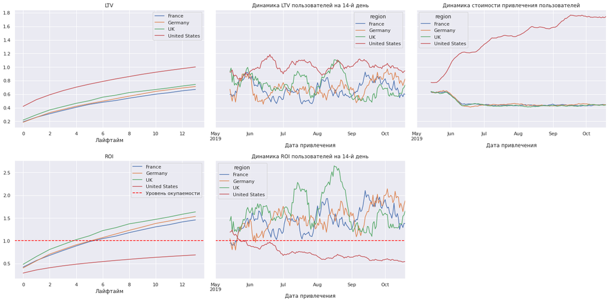

```python
# смотрим окупаемость с разбивкой по странам

dimensions = ['region']

ltv_raw, ltv_grouped, ltv_history, roi_grouped, roi_history = get_ltv(
    profiles, orders, observation_date, horizon_days, dimensions=dimensions
)

plot_ltv_roi(
    ltv_grouped, ltv_history, roi_grouped, roi_history, horizon_days, window=14
)
```

Заметим, что уровень окупаемости самый низкий в США, при наибольшей доле пользователей в этой стране, именно в США пользователи и не окупаются, что связано с самой высокой стоимостью их привлечения.

**Проанализируем окупаемость рекламы с разбивкой по рекламным каналам. Построим графики LTV и ROI, а также графики динамики LTV, CAC и ROI**

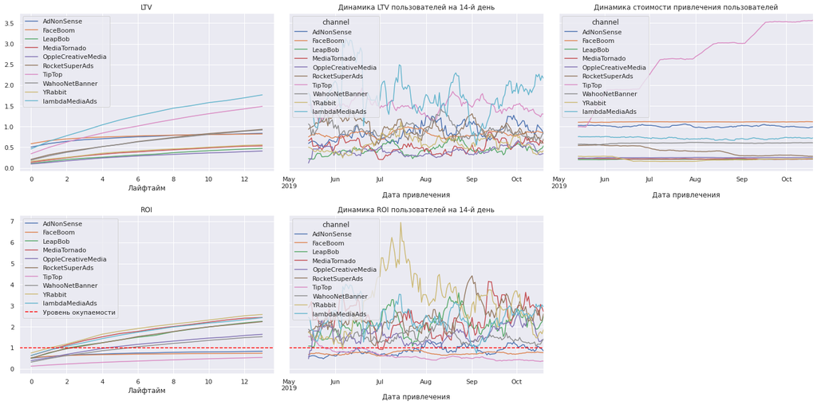

```python
# смотрим окупаемость с разбивкой по источникам привлечения

dimensions = ['channel']

ltv_raw, ltv_grouped, ltv_history, roi_grouped, roi_history = get_ltv(
    profiles, orders, observation_date, horizon_days, dimensions=dimensions
)

plot_ltv_roi(
    ltv_grouped, ltv_history, roi_grouped, roi_history, horizon_days, window=14
)
```

Не окупились пользователи, привлеченные из каналов AdNonSense, FaceBoom, TipTop, при наибольших затратах на TipTop, именно поэтому стоит задуматься об отмене закупки рекламы на этих каналах.

**Окупается ли реклама, направленная на привлечение пользователей в целом?**

Реклама не окупилась, убыток составил 20% рекламного бюджета.

**Какие устройства, страны и рекламные каналы могут оказывать негативное влияние на окупаемость рекламы?**

Негативно влияют на окупаемость владельцы Iphone и Mac, а также пользователи из США и каналы AdNonSense, FaceBoom и TipTop.

**Чем могут быть вызваны проблемы окупаемости?**

Проблема окупаемости, вероятно, связана именно с маркетинговой компанией, при самой высокой стоимости привлечения клиента из США туда и тратится больше денег, также стоит отказаться от некоторых каналов привлечения клиентов либо сократить на них расходы (каналы AdNonSense, FaceBoom и TipTop).

### Напишите выводы

- Выделите причины неэффективности привлечения пользователей.
- Сформулируйте рекомендации для отдела маркетинга.

1) Таким образом, была выполнена предобработка данных, а именно: изменены типы данных у столбцов с датой и временем, все названия столбцов были приведены к нижнему регистру, дубликатов в строках ни в одной из трёх таблиц не найдено, пропуски в данных не обнаружены.

В таблице о заказах 40212 записей, 8881 пользователей оформивших заказы, а в таблице с затратами на маркетинг 1800 записей с 180 уникальными датами.

2) Был задан момент анализа зададим 1 ноября 2019 года, а горизонт анализа 14 дней, были заданы функции для расчёта и анализа LTV, ROI, удержания и конверсии.

3) Были определены лидеры стран по количеству пользователей - больше всего пользователей приходит из США (100002 пользователей или 66,7%), следом идут пользователи из Великобритании и Франции (по 11%), и меньше всего пользователей из Германии(10%).

Разбивка по платящим клиентам немного отличается, лидером опять является СЩА с показателем 6902 пользователя или 6,9% от числа всех пользователей из США, следом идет Германия с показателем 4,1%, у Великабритании 4%, а у Франции 3,8%.

Разбивка по устройствам выглдит следующим образом, iPhone (36,3%), следом Android (23,4%), и по 20% у PC и Mac.

Доля платящих примерно равная на устройствах, но больше у Mac(6,4%) и iPhone (6,2%), у Android 5,9%, PC 5%

Лидеры каналов привлечения идут каналы: organic - 37,6% FaceBoom - 19,4% TipTop - 13,0% По параметру платящих клиентов лидируют каналы: FaceBoom - 12,2 AdNonSense - 11,3% lambdaMediaAds - 10,5%

4) При общей сумме затрат на маркетинг 105497.3, Половина всех трат приходится на TipTop (51,9%), далее идет на FaceBoom с показателем 30,8%, по другим каналам сумма не превышала 5%.

Заметен рост затрат на протяжении всего периода у TipTop и FaceBoom, но следует заметить, что прослеживается увелечение средней стоимости привлечения одного клиента у TipTop с 1 до 3,5, при относительной стабильности других каналов (не более 1,5), что может быть сигналом для пересмотра рекламного бюджета на данный канал.

5) И в конце концов, делаем вывод, что реклама не окупилась, убыток составил 20% рекламного бюджета.

Негативно влияют на окупаемость владельцы Iphone и Mac, а также пользователи из США и каналы AdNonSense, FaceBoom и TipTop.

Проблема окупаемости, вероятно, связана именно с маркетинговой компанией, при самой высокой стоимости привлечения клиента из США туда и тратится больше денег, также стоит отказаться от некоторых каналов привлечения клиентов либо сократить на них расходы (каналы AdNonSense, FaceBoom и TipTop). Рекламный бюджет необходимо пересмотреть в пользу каналов Yrabbit и RocketSuperAds.